# Classification

Jeu de données res.PCA

.

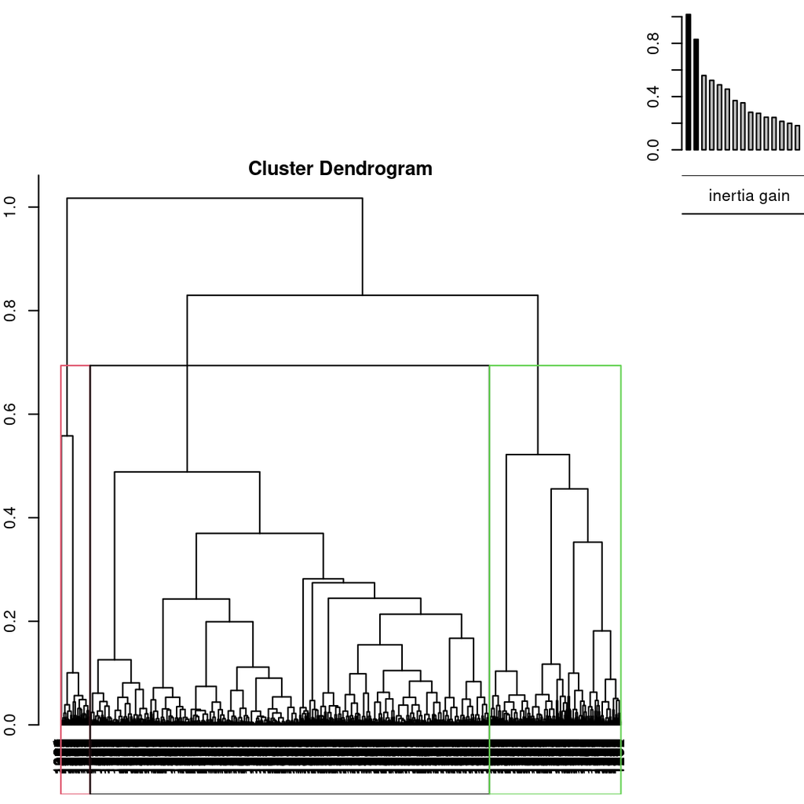

**Figure 1.1 - Arbre hiérarchique.**

La classification réalisée sur les individus fait apparaître 3 classes.

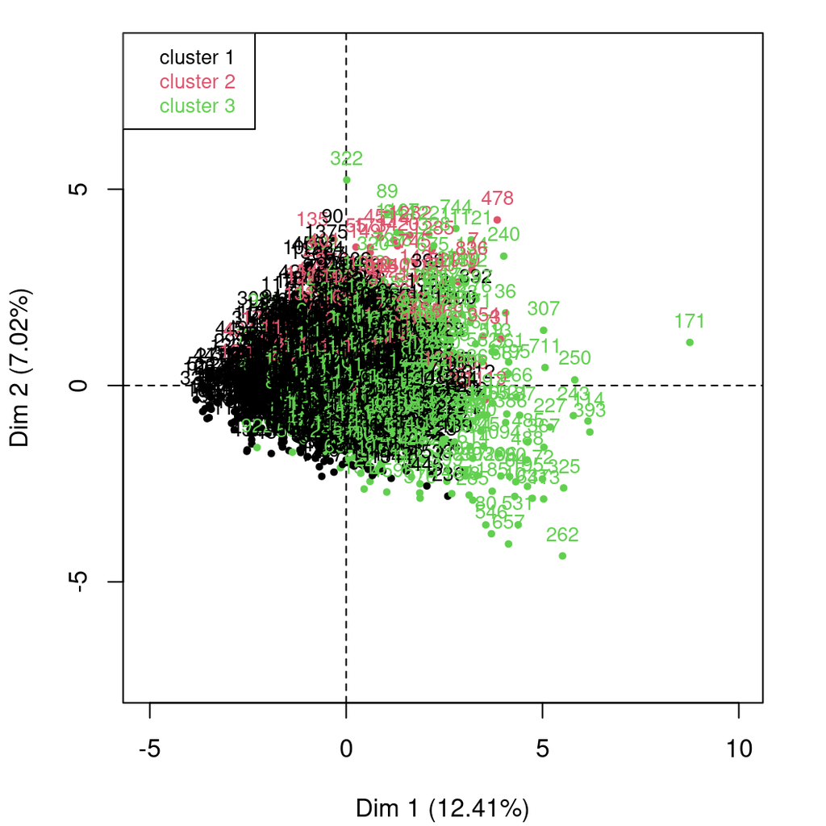

**Figure 1.2 - Classification Ascendante Hiérachique des individus.**

La **classe 1** est composé d’individus partageant :

- de faibles valeurs pour des variables telles que *QPE2b*, *ICOS5*, *QPP2b*, *ICOS4*, *ICOS3*, *QME3b*, *QPE1b*, *LVLb*, *QME1b* et *ICOS2* (de la plus extrême à la moins extrême).

La **classe 2** est composé d’individus partageant :

- de fortes valeurs pour les variables *QPP2b*, *QPP1b*, *QPE1b*, *QME2b* et *QPD1b* (de la plus extrême à la moins extrême).

La **classe 3** est composé d’individus partageant :

- de fortes valeurs pour des variables telles que *QPE2b*, *ICOS5*, *ICOS4*, *ICOS3*, *QME3b*, *LVLb*, *QME1b*, *ICOS2*, *QPE1b* et *ICOS1* (de la plus extrême à la moins extrême).
- de faibles valeurs pour les variables *QPP2b* et *QPP1b* (de la plus extrême à la moins extrême).

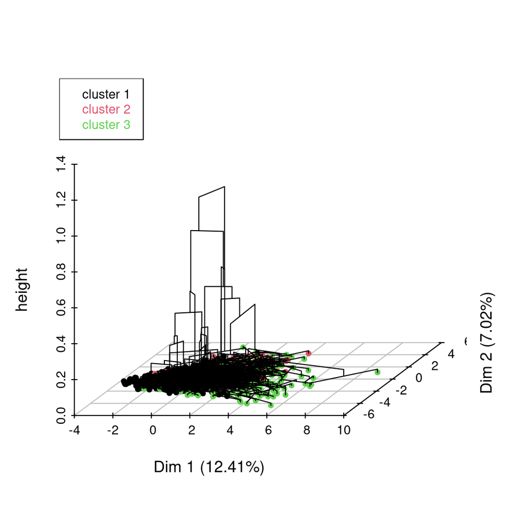

**Figure 1.3 - Arbre hiérarchique sur le plan factoriel.**

The hierarchical tree can be drawn on the factorial map with the individuals colored according to their clusters.